# R Notebook

```r
library(caTools)
library(rpart)
library(rattle)
library(rpart.plot)
library(RColorBrewer)
library(caret)
library(dplyr)
```

```r
churn <- read.csv("churn.csv")
```

1. Inspect the data for any extreme, missing, or non-typical values. Everything should be either numerical and an expected range or categorical with expected responses.

```r
summary(churn)
```

```
     Sex            Marital_Status          Term      Phone_service      International_plan Voice_mail_plan    Multiple_line      Internet_service
 Length:1000        Length:1000        Min.   : 0.0   Length:1000        Length:1000        Length:1000        Length:1000        Length:1000
 Class :character   Class :character   1st Qu.: 8.0   Class :character   Class :character   Class :character   Class :character   Class :character
 Mode  :character   Mode  :character   Median :30.0   Mode  :character   Mode  :character   Mode  :character   Mode  :character   Mode  :character
                                       Mean   :32.8
                                       3rd Qu.:57.0
                                       Max.   :72.0
 Technical_support  Streaming_Videos   Agreement_period   Monthly_Charges  Total_Charges       Churn
 Length:1000        Length:1000        Length:1000        Min.   : 18.95   Min.   :   5.0   Length:1000
 Class :character   Class :character   Class :character   1st Qu.: 40.16   1st Qu.: 334.8   Class :character
 Mode  :character   Mode  :character   Mode  :character   Median : 74.72   Median :1442.3   Mode  :character
                                                          Mean   : 66.64   Mean   :2351.6
                                                          3rd Qu.: 90.88   3rd Qu.:4016.8
                                                          Max.   :116.25   Max.   :8476.5
```

2. Split your data into test and training sets. Common split ratios are anywhere from 70:30 to 80:20. ## Split the data into a training set and test test

```r
set.seed(43)
sample <- sample.split(churn$Churn,SplitRatio=0.7)
train <- subset(churn,sample==TRUE)
test <- subset(churn,sample==FALSE)
```

3. Create an initial decision tree model with Churn as your class label and all of the other variables as attributes. ## Creating the Full Tree Model

```r
tree <- rpart(Churn ~ ., data=train, method = "class",
                     parms = list(split = 'information'),cp=-1)
tree
```

```
n= 700

node), split, n, loss, yval, (yprob)
      * denotes terminal node

   1) root 700 181 No (0.74142857 0.25857143)
     2) Agreement_period=One year contract,Two year contract 335  24 No (0.92835821 0.07164179)
       4) Total_Charges< 4226.85 197   5 No (0.97461929 0.02538071)
         8) Multiple_line=Yes 66   0 No (1.00000000 0.00000000) *
         9) Multiple_line=No,No phone  131   5 No (0.96183206 0.03816794)
          18) International_plan=yes 39   0 No (1.00000000 0.00000000) *
          19) International_plan=No,Yes 92   5 No (0.94565217 0.05434783)
            38) Total_Charges>=2614.275 25   0 No (1.00000000 0.00000000) *
            39) Total_Charges< 2614.275 67   5 No (0.92537313 0.07462687)
              78) Technical_support=No,No internet  46   2 No (0.95652174 0.04347826)
               156) Monthly_Charges>=20.125 22   0 No (1.00000000 0.00000000) *
               157) Monthly_Charges< 20.125 24   2 No (0.91666667 0.08333333)
                 314) Total_Charges>=899.5 9   0 No (1.00000000 0.00000000) *
                 315) Total_Charges< 899.5 15   2 No (0.86666667 0.13333333) *
              79) Technical_support=Yes 21   3 No (0.85714286 0.14285714)
               158) Monthly_Charges>=52.075 14   1 No (0.92857143 0.07142857) *
               159) Monthly_Charges< 52.075 7   2 No (0.71428571 0.28571429) *
       5) Total_Charges>=4226.85 138  19 No (0.86231884 0.13768116)
        10) Term>=63.5 89   6 No (0.93258427 0.06741573)
          20) Total_Charges>=4859.925 81   4 No (0.95061728 0.04938272)
            40) Monthly_Charges< 80.325 16   0 No (1.00000000 0.00000000) *
            41) Monthly_Charges>=80.325 65   4 No (0.93846154 0.06153846)
              82) Monthly_Charges>=90.2 43   1 No (0.97674419 0.02325581)
               164) Total_Charges< 8352.6 35   0 No (1.00000000 0.00000000) *
               165) Total_Charges>=8352.6 8   1 No (0.87500000 0.12500000) *
              83) Monthly_Charges< 90.2 22   3 No (0.86363636 0.13636364)
               166) Streaming_Videos=Yes 15   1 No (0.93333333 0.06666667) *
               167) Streaming_Videos=No 7   2 No (0.71428571 0.28571429) *
          21) Total_Charges< 4859.925 8   2 No (0.75000000 0.25000000) *
        11) Term< 63.5 49  13 No (0.73469388 0.26530612)
          22) Total_Charges< 4962.775 21   2 No (0.90476190 0.09523810)
            44) Internet_service=Fiber optic 10   0 No (1.00000000 0.00000000) *
            45) Internet_service=Cable,DSL 11   2 No (0.81818182 0.18181818) *
          23) Total_Charges>=4962.775 28  11 No (0.60714286 0.39285714)
            46) Technical_support=Yes 10   2 No (0.80000000 0.20000000) *
```

[output cut: 39 more lines]

```
                      3817) Internet_service=Fiber optic 16   5 Yes (0.31250000 0.68750000) *
                    1909) Sex=Male 15   2 Yes (0.13333333 0.86666667) *
                   955) Multiple_line=Yes 18   2 Yes (0.11111111 0.88888889) *
               239) Monthly_Charges< 62.125 27   3 Yes (0.11111111 0.88888889)
                 478) Marital_Status=Single 16   3 Yes (0.18750000 0.81250000) *
                 479) Marital_Status=Married 11   0 Yes (0.00000000 1.00000000) *
        15) Monthly_Charges>=94.925 66  15 Yes (0.22727273 0.77272727)
          30) Monthly_Charges>=106.675 11   4 No (0.63636364 0.36363636) *
          31) Monthly_Charges< 106.675 55   8 Yes (0.14545455 0.85454545)
            62) Technical_support=Yes 17   6 Yes (0.35294118 0.64705882) *
            63) Technical_support=No 38   2 Yes (0.05263158 0.94736842)
             126) International_plan=Yes 20   2 Yes (0.10000000 0.90000000)
               252) Sex=Male 8   2 Yes (0.25000000 0.75000000) *
               253) Sex=Female 12   0 Yes (0.00000000 1.00000000) *
             127) International_plan=No,yes 18   0 Yes (0.00000000 1.00000000) *
```

[figure not shown]

```r
fancyRpartPlot(tree)
```

4. Check the accuracy of your full model with Accuracy and F1 scores. ## Calculate the Predictions from the test data

```r
pred <-predict(tree,test,type = "class")
```

## Calculate the Confusion Matrix and fit measures

```r
conf <- table(pred,test$Churn)
confusionMatrix(conf)
```

```
Confusion Matrix and Statistics


pred   No Yes
  No  193  37
  Yes  29  41

               Accuracy : 0.78
                 95% CI : (0.7288, 0.8256)
    No Information Rate : 0.74
    P-Value [Acc > NIR] : 0.06317

                  Kappa : 0.4086

 Mcnemar's Test P-Value : 0.38889

            Sensitivity : 0.8694
            Specificity : 0.5256
         Pos Pred Value : 0.8391
         Neg Pred Value : 0.5857
             Prevalence : 0.7400
         Detection Rate : 0.6433
   Detection Prevalence : 0.7667
      Balanced Accuracy : 0.6975

       'Positive' Class : No
```

```r
confusionMatrix(conf)$byClass
```

```
         Sensitivity          Specificity       Pos Pred Value       Neg Pred Value            Precision               Recall                   F1
           0.8693694            0.5256410            0.8391304            0.5857143            0.8391304            0.8693694            0.8539823
          Prevalence       Detection Rate Detection Prevalence    Balanced Accuracy
           0.7400000            0.6433333            0.7666667            0.6975052
```

Accuracy: 0.78 F1: 0.854

5. Create a pre-pruned decision tree by setting stop parameters. ## Pre-Pruning Method ## Fit the Model

```r
pre_tree <-  rpart(Churn ~ ., data=train, method = "class",
               parms = list(split = 'information'),maxdepth = 4, minsplit = 10, minbucket = 5)
pre_tree
```

```
n= 700

node), split, n, loss, yval, (yprob)
      * denotes terminal node

 1) root 700 181 No (0.74142857 0.25857143)
   2) Agreement_period=One year contract,Two year contract 335  24 No (0.92835821 0.07164179) *
   3) Agreement_period=Monthly contract 365 157 No (0.56986301 0.43013699)
     6) Monthly_Charges< 32.4 73   9 No (0.87671233 0.12328767) *
     7) Monthly_Charges>=32.4 292 144 Yes (0.49315068 0.50684932)
      14) Monthly_Charges< 94.925 226  97 No (0.57079646 0.42920354)
        28) Total_Charges>=803.025 105  24 No (0.77142857 0.22857143) *
        29) Total_Charges< 803.025 121  48 Yes (0.39669421 0.60330579) *
      15) Monthly_Charges>=94.925 66  15 Yes (0.22727273 0.77272727)
        30) Monthly_Charges>=106.675 11   4 No (0.63636364 0.36363636) *
        31) Monthly_Charges< 106.675 55   8 Yes (0.14545455 0.85454545) *
```

[figure not shown]

```r
fancyRpartPlot(pre_tree)
```

6. Check the accuracy of your pre-pruned model with Accuracy and F1 scores. ## Make the predictions

```r
pre_pred<-predict(pre_tree,test,type = "class")
```

## Measures of Fit

```r
pre_conf <- table(pre_pred,test$Churn)
confusionMatrix(pre_conf)
```

```
Confusion Matrix and Statistics


pre_pred  No Yes
     No  185  32
     Yes  37  46

               Accuracy : 0.77
                 95% CI : (0.7182, 0.8164)
    No Information Rate : 0.74
    P-Value [Acc > NIR] : 0.1310

                  Kappa : 0.4145

 Mcnemar's Test P-Value : 0.6301

            Sensitivity : 0.8333
            Specificity : 0.5897
         Pos Pred Value : 0.8525
         Neg Pred Value : 0.5542
             Prevalence : 0.7400
         Detection Rate : 0.6167
   Detection Prevalence : 0.7233
      Balanced Accuracy : 0.7115

       'Positive' Class : No
```

```r
confusionMatrix(pre_conf)$byClass
```

```
         Sensitivity          Specificity       Pos Pred Value       Neg Pred Value            Precision               Recall                   F1
           0.8333333            0.5897436            0.8525346            0.5542169            0.8525346            0.8333333            0.8428246
          Prevalence       Detection Rate Detection Prevalence    Balanced Accuracy
           0.7400000            0.6166667            0.7233333            0.7115385
```

Accuracy: 0.77 F1: 0.843

7. Create a post-pruned decision tree by finding an optimal complexity parameter. ## Post-Pruning Method ## Find the CP

```r
printcp(tree)
```

```
Classification tree:
rpart(formula = Churn ~ ., data = train, method = "class", parms = list(split = "information"),
    cp = -1)

Variables actually used in tree construction:
 [1] Agreement_period   International_plan Internet_service   Marital_Status     Monthly_Charges    Multiple_line      Phone_service      Sex
 [9] Streaming_Videos   Technical_support  Term               Total_Charges

Root node error: 181/700 = 0.25857

n= 700

          CP nsplit rel error  xerror     xstd
1  0.0662983      0   1.00000 1.00000 0.064002
2  0.0165746      5   0.59116 0.65193 0.054724
3  0.0092081      9   0.52486 0.66298 0.055091
4  0.0055249     12   0.49724 0.67956 0.055630
5  0.0000000     13   0.49171 0.73481 0.057344
6 -1.0000000     44   0.49171 0.73481 0.057344
```

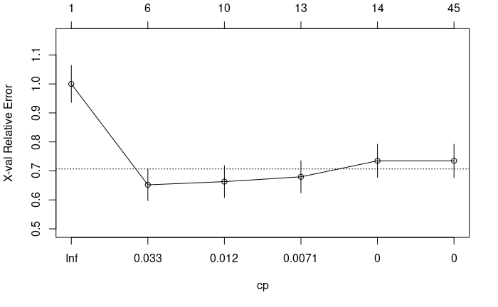

```r
plotcp(tree)
```

```r
cp = tree$cptable[which.min(tree$cptable[,"xerror"]),"CP"]
```

## Fit the Model

```r
post_tree <- rpart(Churn ~ ., data=train, method = "class",
             parms = list(split = 'information'),cp=cp)
post_tree
```

```
n= 700

node), split, n, loss, yval, (yprob)
      * denotes terminal node

 1) root 700 181 No (0.74142857 0.25857143)
   2) Agreement_period=One year contract,Two year contract 335  24 No (0.92835821 0.07164179) *
   3) Agreement_period=Monthly contract 365 157 No (0.56986301 0.43013699)
     6) Monthly_Charges< 32.4 73   9 No (0.87671233 0.12328767) *
     7) Monthly_Charges>=32.4 292 144 Yes (0.49315068 0.50684932)
      14) Monthly_Charges< 94.925 226  97 No (0.57079646 0.42920354)
        28) Total_Charges>=803.025 105  24 No (0.77142857 0.22857143) *
        29) Total_Charges< 803.025 121  48 Yes (0.39669421 0.60330579)
          58) Total_Charges< 44.4 23   5 No (0.78260870 0.21739130) *
          59) Total_Charges>=44.4 98  30 Yes (0.30612245 0.69387755) *
      15) Monthly_Charges>=94.925 66  15 Yes (0.22727273 0.77272727) *
```

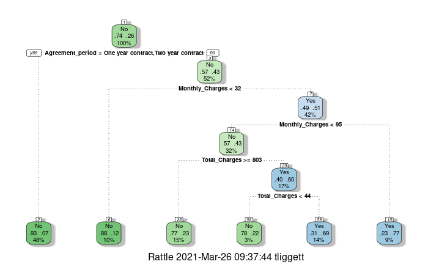

```r
fancyRpartPlot(post_tree)
```

8. Check the accuracy of your post-pruned model Accuracy and F1 scores. ## Make the Predictions

```r
post_pred<-predict(post_tree,test,type = "class")
```

## Measures of Fit

```r
post_conf <- table(post_pred,test$Churn)
confusionMatrix(post_conf)
```

```
Confusion Matrix and Statistics


post_pred  No Yes
      No  195  31
      Yes  27  47

               Accuracy : 0.8067
                 95% CI : (0.7574, 0.8498)
    No Information Rate : 0.74
    P-Value [Acc > NIR] : 0.004204

                  Kappa : 0.4891

 Mcnemar's Test P-Value : 0.693641

            Sensitivity : 0.8784
            Specificity : 0.6026
         Pos Pred Value : 0.8628
         Neg Pred Value : 0.6351
             Prevalence : 0.7400
         Detection Rate : 0.6500
   Detection Prevalence : 0.7533
      Balanced Accuracy : 0.7405

       'Positive' Class : No
```

```r
confusionMatrix(post_conf)$byClass
```

```
         Sensitivity          Specificity       Pos Pred Value       Neg Pred Value            Precision               Recall                   F1
           0.8783784            0.6025641            0.8628319            0.6351351            0.8628319            0.8783784            0.8705357
          Prevalence       Detection Rate Detection Prevalence    Balanced Accuracy
           0.7400000            0.6500000            0.7533333            0.7404712
```

Accuracy: 0.807 F1: 0.871

9. Select your final model based on your fit metrics.

We chose to use the post prune model because it gave us both the highest accuracy and F1 scores of our models.

```r
churn_group3 <- read.csv("group3churn.csv")

# Fixing no internet values that were having some issues.
churn_group3$Internet_service[churn_group3$Internet_service == "No internet"] <- "No internet "
churn_group3$Technical_support[churn_group3$Technical_support == "No internet"] <- "No internet "
churn_group3$Streaming_Videos[churn_group3$Streaming_Videos == "No internet"] <- "No internet "

# The Total_Charges needs to be a numeric as before, get rid of the commas.
churn_group3$Total_Charges <- as.numeric(gsub(",", "", churn_group3$Total_Charges))

# Here we predict our churn
churn_group3$Churn <-predict(post_tree,churn_group3,type = "class")

churn_group3 %>%
  select(Name, Churn)
```

| Name | Churn |
| --- | --- |
| Nathan Caldwell | No |
| Ellen Tate | No |
| Nicole Black | Yes |
| Fernando Robbins | No |
| Holly Hampton | No |
| Samantha Mathis | No |
| Manuel Gross | Yes |
| Cody Reed | Yes |
| Viola Spencer | No |
| Rex Estrada | No |

## A short write-up on which model you chose to deploy and rationale for it.

We chose to use the post prune model because it gave us both the highest accuracy and F1 scores of our models.

## A short write-up on which factors were most important in determining who is at risk of churning.

The most important factors for determining who is at risk of churning were agreement period, monthly charges, and total charges. These were the factors that were used in our post prune model.

## A short write-up on which customers should be recommended for the promotion rate.

```r
churn_group3 %>% select(Name, Churn)
```

| Name | Churn |
| --- | --- |
| Nathan Caldwell | No |
| Ellen Tate | No |
| Nicole Black | Yes |
| Fernando Robbins | No |
| Holly Hampton | No |
| Samantha Mathis | No |
| Manuel Gross | Yes |
| Cody Reed | Yes |
| Viola Spencer | No |
| Rex Estrada | No |

We would recommend Nicole Black, Manuel Gross, and Cody Reed for the promotion rate. These were the customers that our model predicted would churn. Giving them a promotional rate might keep them with the company longer.